# R Notebook-Pepperwood Hobo Data Analysis

```r
knitr::opts_chunk$set(echo = TRUE)
library(ggplot2)
library(dplyr)
```

R Markdown - Individual files

```r
pws <-read.csv("data/PPW_HOBO_2015_Master.csv")
str(pws)
summary(pws)
```

Check the imported columns

```r
str(pws)
head(pws)
pws$tsfmt<- as.POSIXct(pws$Date.Time,format="%Y-%m-%d %H:%M:%S")
head(pws)
```

Lets try to do the summary by site, day for the 2015 data for RH and Temperature

```r
head(pws %>%mutate(HR= format(tsfmt,"%H"),DATE=format(tsfmt,"%Y-%m-%d")) %>% group_by(Plot,DATE,HR) %>% summarise(minHrlyTemp = min(Temp),maxHrlyTemp = max(Temp),meanHrlyTemp = mean(Temp),minHrlyRH = min(RH),maxHrlyRH = max(RH),meanHrlyRH = mean(RH)) %>% as.data.frame())
```

Lets write to CSV

```r
pws %>%mutate(HR= format(tsfmt,"%H"),DATE=format(tsfmt,"%Y-%m-%d")) %>% group_by(Plot,DATE,HR) %>% summarise(minHrlyTemp = min(Temp),maxHrlyTemp = max(Temp),meanHrlyTemp = mean(Temp),minHrlyRH = min(RH),maxHrlyRH = max(RH),meanHrlyRH = mean(RH)) %>% as.data.frame() %>% write.csv("data/Hobo-2015-Summary-Hourly.csv")
```

Now, lets create the daily file. We can follow the same, but now summarize by DATE

```r
pws %>%mutate(HR= format(tsfmt,"%H"),DATE=format(tsfmt,"%Y-%m-%d")) %>% group_by(Plot,DATE) %>% summarise(minHrlyTemp = min(Temp),maxHrlyTemp = max(Temp),maxHrlyTemp = max(Temp),minHrlyRH = min(RH),maxHrlyRH = max(RH),meanHrlyRH = mean(RH)) %>% as.data.frame() %>% write.csv("data/Hobo-2015-Summary-Daily.csv")
```

Lets validate our files, criteria a) Number of collection points

```r
ht2015<- read.csv('./data/Hobo-2015-Summary-Hourly.csv')
str(ht2015)
head(ht2015)
```

Housekeeping , convert date from factor to a datetype, and add Month

```r
ht2015$dt <- as.Date(ht2015$DATE, "%Y-%m-%d")
str(ht2015)
# Check for the Sanity of data
summary(ht2015)
```

There are some corrupt values in Temperature, research the issue

```r
ht2015$dt <- as.Date(ht2015$DATE, "%Y-%m-%d")
str(ht2015)
# Check for the Sanity of data
summary(ht2015)
```

Plot the number of collections by day

```r
ht2015 %>% mutate(site = as.factor(Plot)) %>%
group_by(site) %>%
summarise(total = n()) %>% ggplot(aes(x=site,fill=total)) +
geom_bar() +
theme(axis.text.x = element_text(angle = 90, hjust = 1))
```

Different way of looking at same, we expect for each plot 24 points for a day, so that makes it 24*365 (approx 8760 points for a site) . We get 2 by site every hour.

```r
ht2015 %>%  mutate(site = as.factor(Plot)) %>%
group_by(site) %>%
summarise(total = n()) %>% ggplot(aes(x=site,y=total)) +
geom_point() +
theme(axis.text.x = element_text(angle = 90, hjust = 1))
```

Issue with 1328 collection, so have less than half the required points, so we can drop it from analysis.

Now, lets look at the unusually high temperatures

```r
ht2015 %>% group_by(dt)  %>% summarise(avg_temp=mean(meanHrlyTemp)) %>% ggplot(aes(dt,avg_temp)) +
geom_point() + geom_smooth(alpha=.2, size=2)
```

So, mostly looks good, except some months are suspicious, lets look at it closer.

```r
p1 <- ggplot(ht2015, aes(factor(Plot), meanHrlyTemp))
p1 <- p1 + geom_boxplot(aes(fill = factor(Plot)),outlier.colour = "red", outlier.size = 3) + theme(axis.text.x = element_text(angle = 90, hjust = 1),legend.position="none") + ggtitle("Mean temperatures across Pepperwood") + xlab("Site") +
ylab("Mean. Temperatures")+ stat_summary(fun.y=mean, geom="line", aes(group=1))  +
stat_summary(fun.y=mean, geom="point")
p1
```

Issue with 1328 , putting it all out of whack.

```r
p1 <- ggplot(ht2015 %>% filter(!(Plot %in% c(1328))), aes(factor(Plot), meanHrlyTemp))
p1 <- p1 + geom_boxplot(aes(fill = factor(Plot)),outlier.colour = "red", outlier.size = 3) + theme(axis.text.x = element_text(angle = 90, hjust = 1),legend.position="none") + ggtitle("Mean temperatures across Pepperwood") + xlab("Site") +
ylab("Mean. Temperatures")+ stat_summary(fun.y=mean, geom="line", aes(group=1))  +
stat_summary(fun.y=mean, geom="point")
p1
```

```r
str(ht2015)
head(ht2015 %>% mutate(MONTH= format(dt,"%m"),DAY= format(dt,"%d")) %>% as.data.frame())
```

```r
str(ht2015)
head(ht2015 %>% mutate(MONTH= format(dt,"%m"),DAY= format(dt,"%d")) %>% as.data.frame())
```

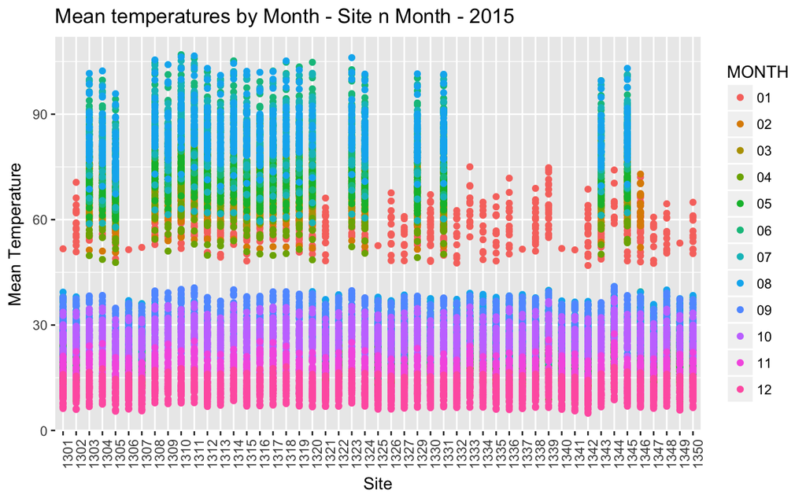

```r
ht2015$site<- as.factor(ht2015$Plot)
ht2015 %>% filter(!(Plot %in% c(1328))) %>% mutate(MONTH= format(dt,"%m"),DAY= format(dt,"%d")) %>% filter(MONTH %in% c('01','02','03','04','05','06','07','08','09','10','11','12')) %>% group_by(site,MONTH,DAY) %>%
    summarise(
              min_temp = min(meanHrlyTemp),
              max_temp = max(meanHrlyTemp),
              mean_temp = max(meanHrlyTemp),
              diu_fluct = max_temp - min_temp ,
              total = n()) %>% ggplot(aes(site,mean_temp, color=MONTH)) + geom_point() +  theme(axis.text.x = element_text(angle = 90, hjust = 1)) + ggtitle("Mean temperatures by Month - Site n Month - 2015") + xlab("Site") + ylab("Mean Temperature")
```

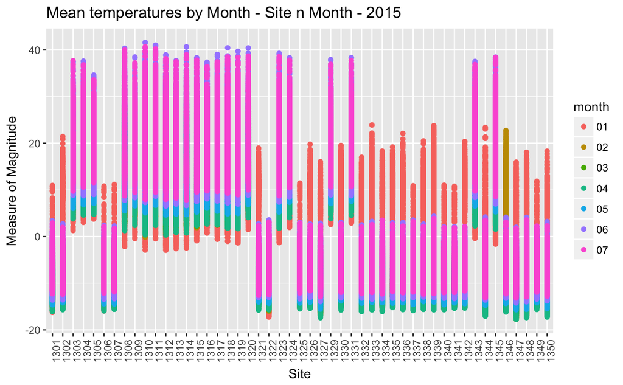

```r
ht2015$month<- format(ht2015$dt,"%m")
ht2015 %>% filter(!(Plot %in% c(1328))) %>%  filter(month %in% c('01','02','03','04','05','06','07')) %>% mutate(meanHrlyTempFix = (((meanHrlyTemp-32)*5)/9)) %>%  ggplot(aes(site,meanHrlyTempFix, color=month)) + geom_point() +  theme(axis.text.x = element_text(angle = 90, hjust = 1)) + ggtitle("Mean temperatures by Month - Site n Month - 2015") + xlab("Site") + ylab("Measure of Magnitude")
```

```r
ht2015$site<- as.factor(ht2015$Plot)
ht2015 %>% filter(!(Plot %in% c(1328))) %>% mutate(MONTH= format(dt,"%m"),DAY= format(dt,"%d")) %>% filter(MONTH %in% c('01','02','03','04','05','06','07','08','09','10','11','12')) %>% group_by(site,MONTH,DAY) %>%
    summarise(
              min_temp = min(meanHrlyTemp),
              max_temp = max(meanHrlyTemp),
              diu_fluct = max_temp - min_temp ,
              total = n()) %>% ggplot(aes(site,diu_fluct, color=MONTH)) + geom_point() +  theme(axis.text.x = element_text(angle = 90, hjust = 1)) + ggtitle("Diurnal fluctuation - Site n Month - 2015") + xlab("Site") + ylab("Measure of Magnitude")
```